# Continous Random Variables

A random variable $X$ is called continous if there is a nonnegative function $f_{X}$ called the probability density function of $X$, or PDF for short, such that:

$P(X \in B ) = \int_{B} f_{X}(x)dx$

For every subset $B$ of the real line. In particular, the probabilit that the value of $X$ falls within an interval is:

$P(a \leq X \leq b ) = \int_{a}^{b} f_{X}(x)$

and can be interpreted as the area under the graph of the PDF. For any single value $a$, we have

$P(X=a)=P(X=b)=0$

For this reason, including or excluding the endpoints of an interval has no effect on its probability:

$$P(a \leq X \leq b ) = P(a < X \leq b ) = P(a \leq X < b ) = P(a< X < b )$$

Note that to qualify as a PDF, a function $f_{X}$ must be nonnegative, i.e,

$f_{X} \geq 0$ for every $x$, and must also have the normalization property:

$$\int_{-\infty}^{\infty} f_{X}(x)dx = P(-\inf<X<\inf)=1$$

### Expectation and Variance of Continous Random Variable and its Properties

- Expected value of $X$

$$E[X]=\int_{-\infty}^{\infty}xf_{X}(x)dx$$

- The expected value rule for a function $g(X)$ has the form

$$E[g(X)] = \int_{-\infty}^{\infty} g(x)f_{X}(x)dx$$

- The variance of $X$

$$var(X)=E[(X-E[X])^2] = \int_{-\infty}^{\infty}(x-E[X])^{2}f_{X}(x)dx$$

- If $Y=aX+b$, where $a$ and $b$ are given scalars, then:

$$E[Y] = aE[X] + b$$
and
$$var(Y)= a^{2}var(X)$$

## Types of Random Variable

### Exponential Random Variable

An *exponential* random variable has a PDF of the form:

$$f_{X}(x) = {\lambda}e^{- x/ \lambda}\qquad \qquad x > 0,$$
Otherwise,
$$f_{X}(x)=0$$

An exponential random variable can, for example, be a good model for the amount of time until an incident of interest takes place, such as a message arriving at a computer, some equipment breaking down, a light bulb burning out, an accident ocurring, etc.

- Expected value

$$E[X] = \frac{1}{\lambda}$$

- Variance

$$var(X) = \frac{1}{{\lambda}^{2}}$$

### Cumulative Distribution Functions

### Normal or Gaussian Distribution Function

A continous random variable $X$ is called *normal* if exists a PDF of the form:

$$f_{X}(x) = \frac{1}{\sqrt{2\sigma}} \int_{-\infty}^{\infty} e^{-(x-\mu)^{2}/2\sigma}$$

- Expected value

$$E[X] = \mu$$

- Variance

$$var(X) = {\sigma}^{2}$$

- In R we can implement

```r
#Normal distribution
set.seed(3000)
#generate x values in the real line
xseq <- seq(-4,4,.01)
#find the probability density function (PDF)
densities <- dnorm(xseq, 0,1)
#cumulative density function (CDF)
cumulative <- pnorm(xseq, 0, 1)
#generate a random sample from normal distribution
randomdeviates <- rnorm(1000,0,1)
# u =0 y variance =1
plot(xseq, densities, col="darkgreen",xlab="",
     ylab="Density", type="l",lwd=2, cex=2,
     main="PDF of Standard Normal 1", cex.axis=.8)
# u =0 y variance = 15
densities <- dnorm(xseq, 0,1.5)
plot(xseq, densities, col="darkgreen",xlab="",
     ylab="Density", type="l",lwd=2, cex=2,
     main="PDF of Standard Normal 2", cex.axis=.8)
```

[output not shown]

# More generally

```r
set.seed(3000)
#vector of X values from the real line
xseq<-seq(-4,4,.01)
#PDF
densities<-dnorm(xseq, 0,1)
#CDF
cumulative<-pnorm(xseq, 0, 1)
#random numbers from the normal distribution
randomdeviates<-rnorm(1000,0,1)

par(mfrow=c(1,3), mar=c(3,4,4,2))
plot(xseq, densities, col="darkgreen",xlab="", ylab="Density", type="l",lwd=2, cex=2, main="PDF of Standard Normal", cex.axis=.8)
plot(xseq, cumulative, col="darkorange", xlab="", ylab="Cumulative Probability",type="l",lwd=2, cex=2, main="CDF of Standard Normal", cex.axis=.8)
```

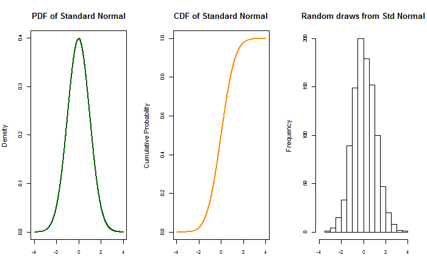

```r
hist(randomdeviates, main="Random draws from Std Normal", cex.axis=.8, xlim=c(-4,4))
```

### Standard Normal Random Variable

$$var(X) = {\sigma}^{2}$$